# Multivariate Visualizations

Your Group’s Names Here!

Due: November 12, 2019

# Evaluation Data – Revisited

The data are gathered from end of semester student evaluations for a large sample of professors from the University of Texas at Austin. These data are merged with descriptors of the professors and the classes. In addition, six students rated the professors’ physical appearance. The result is a data frame where each row contains a different course and each column has information on either the course or the professor.

[Data are available through the Open Intro Statitics course webpage](https://www.openintro.org/stat/data/evals.php).

```r
library(tidyverse)

evals <- read_csv("data/evals.csv") %>%
  rename(sex = gender)
```

# Making a Scatterplot

A scatterplot is a natural way to visualize the relationship between two quantitative variables, where the observations are plotted as ordered pairs using some symbol.

To make a scatterplot in `ggplot2`, we use the same `ggplot()` function to specify our variables, but add a `geom_point()`

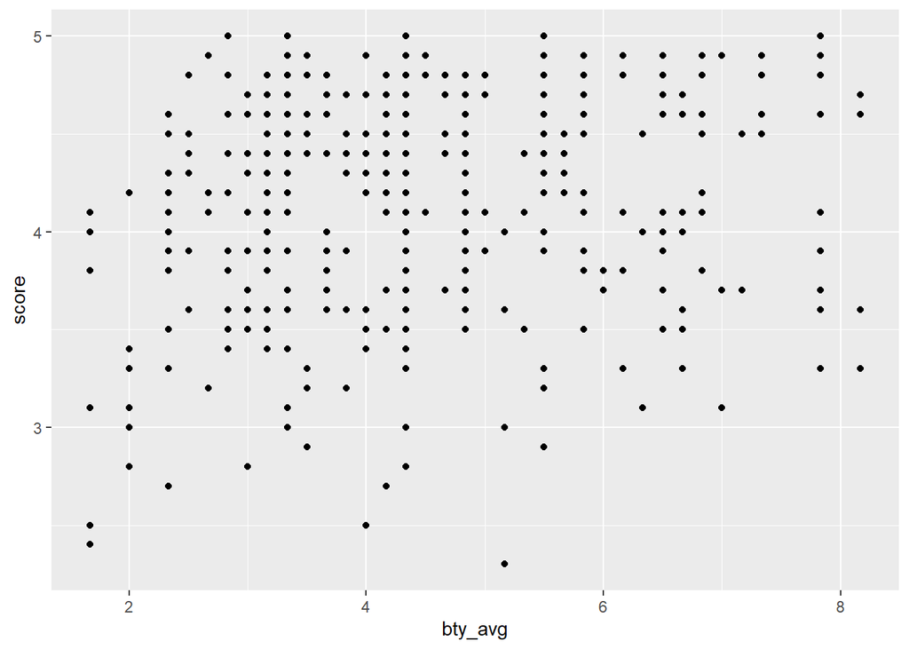

```r
evals %>%
  ggplot(aes(x = bty_avg, y = score)) +
  geom_point()
```

Notice, that it doesn’t appear that the nearly 500 observations from the data are being plotted, since many data points share the same scores. By changing the geom to `geom_jitter()`, like we used to plot the data on top of the violin plots, we can shuffle the data points just a bit to better see the underlying structure.

**1. Change the plot above to use `geom_jitter()`.** **What relationship do you see?**

## Adding Color

We’ve added color to our violin and boxplots by assigning the color aesthetic to a variable in the data. Thus far, however, we have only assigned a categorical variable to the color aesthetic.

## Discrete vs Continuous Variables

**2. Add a color aesthetic to the level of the course.**

**3. Now change the color aesthetic to be the percent of students who completed the evaluation.** **What changed?**

## Adding a Smoother

Smoothers aid the eye in seeing patterns in the presence of overplotting. A smoother adds a “trend” line to the plot.

To add a smoother, you simply add a `geom_smooth()` layer to your `ggplot`.

**4. Add a `geom_smooth()` layer to the plot below.** **What was the default smoothing method `ggplot` chose for you?**

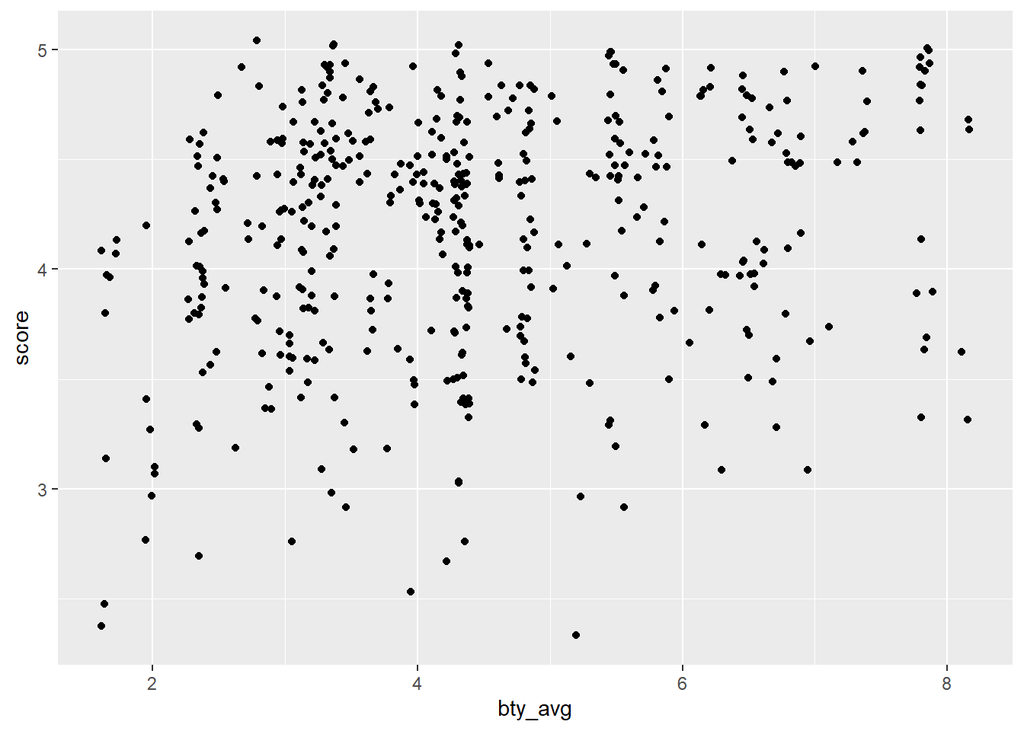

```r
evals %>%
  ggplot(aes(x = bty_avg, y = score)) +
  geom_jitter()
```

### What method to choose?

When adding a smoother to a scatterplot, if you don’t specify what type you want, `ggplot` will choose one for you. It chooses bases on the following rules:

- “loess” is chosen for less than 1,000 observations
- “gam” is chosen otherwise

Note that “lm” (the smoother we want) is **never** a default choice. Therefore, we have to specify a linear smoother, if this is what we want.

**5. Change the smoother used above to be a linear model rather than a “loess”.**

### Smoothers for Groups

When you define aesthetics in the `ggplot()` function, those mappings hold for **every** aspect of your plot.

For example, if you chose to add a smoother to your plot of course evaluation score versus average beauty score, you would get different lines depending on where you define your color aesthetics.

**Globally**

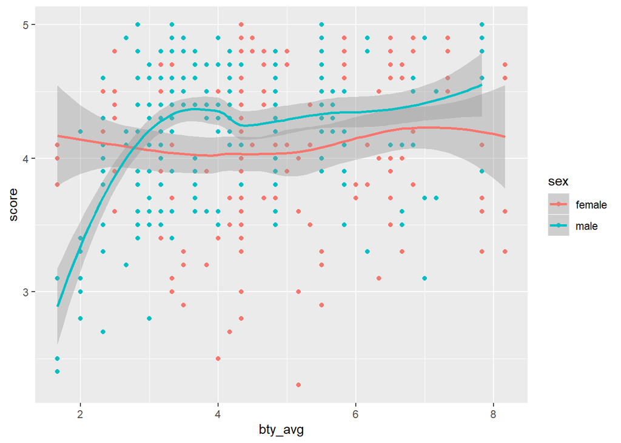

```r
evals %>%
  ggplot(aes(x = bty_avg, y = score, color = sex)) +
  geom_point() +
  geom_smooth()
```

```r
  ## trend line for each sex of professor -- because color is defined globally
```

**Locally**

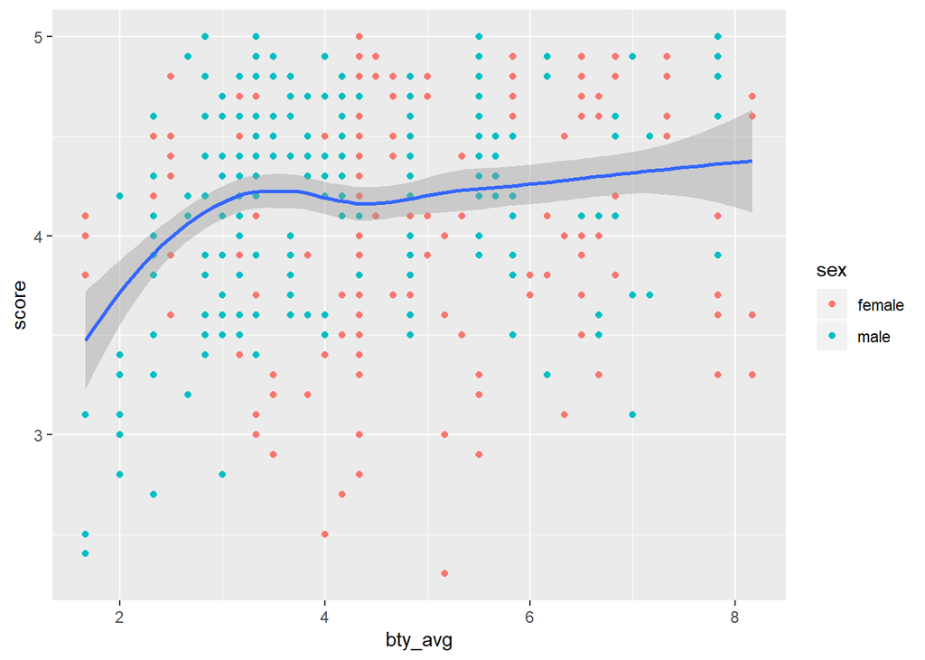

```r
evals %>%
  ggplot(aes(x = bty_avg, y = score)) +
  geom_point(aes(color = sex)) +
  geom_smooth()
```

```r
## one trend line -- no color defined globally
```

# Recreating the Visualizations from Lab 1

```r
ggplot(mapping = aes(x = year, y = percent_yes, color = country)) +
    geom_point() +
    geom_smooth(method = "loess", se = FALSE) +
    facet_wrap(~ issue) +
    labs(
      title = "Percentage of 'Yes' votes in the UN General Assembly",
      subtitle = "1946 to 2015",
      y = "% Yes",
      x = "Year",
      color = "Country"
    )
```

Now that we have the necessary tools, let’s digest what is going on in the plot we created in Lab 1:

- Line 1 defines the variables that are being mapped to different parts of the graph (aesthetics) – x, y, and color have been specified
- Line 2 defines the type of plot to make – here a scatterplot
- Line 3 adds a smoother to the plot and defines what type of smoother should be used – “loess”
- Line 4 defines what variable to facet by – issue
- Lines 5-11 define what labels should be added to the plot – title, subtitle, x, y, and color labels

**6. Using Lab 1 as a template, create a visualization of:**

- The relationship between a professor’s course evaluation score & their average beauty score
- Include:
  - the raw data and linear smoothers
  - different colors for different position rankings
  - separate plots for different sexes of professors

**7. Now add:**

- Nice x- and y-axis labels
- A title describing the data

# Simple Linear Regression Assumptions

Suppose instead that we are interested in modeling the relationship between a professor’s course evaluation score and the percentage of students who completed the evaluation. Additionally, we are interested in knowing if this relationship differs by the level of the course.

## Linearity

**8. Create a visualization that visualizes score as a function of percent eval.** **The plot should:**

- plot the raw data points
- differentiate the data for each group in a meaningful way – colors, facets, etc.

## Normality of Residuals

Technically, all along we’ve been assuming that the residuals of our linear model are normally distributed.

In Lab 4 we made a density plot of the residuals from a linear model, which is exactly what we will do for a simple linear regression.

Recall that to obtain the residuals from the data model, we need to carry out the following steps:

1. Fit a model using `lm`, with a quantitative response and a categorical explanatory
2. Pull off the residuals from the model and store in a new variable in the dataset

Once we’ve done these steps, we can create a density plot or histogram of the model’s residuals. Using this plot, we can assess the assumption of normality of residuals!

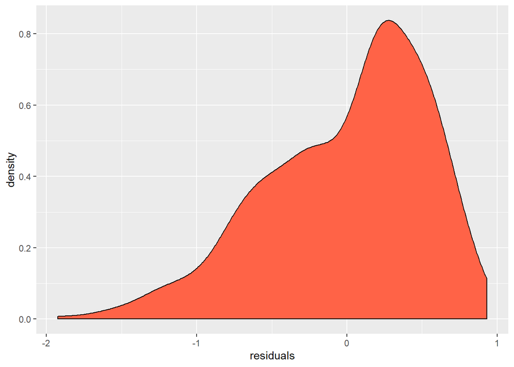

```r
# Fit a linear model to the data
evals_lm <- lm(score ~ bty_avg, data = evals)

evals %>%
  # Create a new variable that's the residuals from the linear model
  mutate(residuals = residuals(evals_lm)) %>%
  # Plot a density plot of the residuals
  ggplot(aes(x = residuals)) +
  # Choose your color!
  geom_density(fill = "tomato")
```

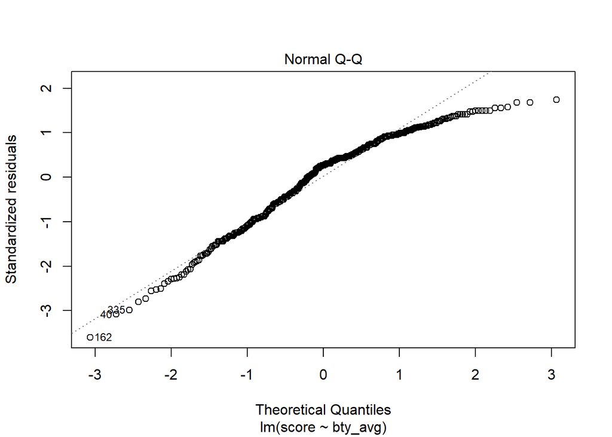

```r
# The standard base R plot for assessing normality of residuals
plot(evals_lm, which = 2)
```

**9. What do you see in the density plot of the residuals from the regression?** **How does this correspond with what you see in the Normal Q-Q plot?**

## Constant Variance

Another assumption of simple linear regression is that the variability across the range of x-values is **the same**.

**10. Using the plot you made for Question 8, discuss what you see in the variability of scores across the range of the percentage of students who completed the evaluation?**

# Optional Topic – Changing Colors in `ggplot`

The built in `ggplot` color scheme may not be what you were looking for, but don’t worry! There are many other color palettes available to use!

You can change the colors used by `ggplot()` a few different ways.

1. Add the `scale_color_manual()` or `scale_fill_manual()` functions to your plot and directly specify the colors you want to use, by:
- defining a vector of colors right there (e.g. c(“blue”, “black”, “red”, “green”))
- creating a vector of colors and storing it in an object and calling on it (see below)

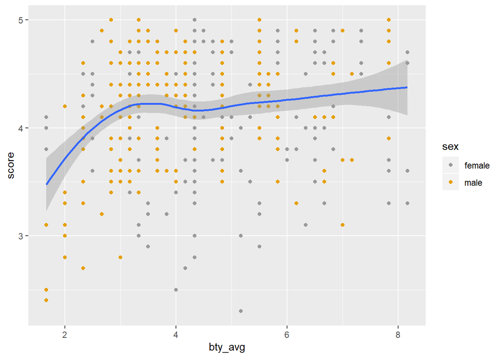

```r
# The palette with grey:
cbPalette_grey <- c("#999999", "#E69F00", "#56B4E9", "#009E73", "#F0E442",
                    "#0072B2", "#D55E00", "#CC79A7")

# The palette with black:
cbbPalette_blk <- c("#000000", "#E69F00", "#56B4E9", "#009E73", "#F0E442",
                    "#0072B2", "#D55E00", "#CC79A7")

evals %>%
  ggplot(aes(x = bty_avg, y = score)) +
  geom_point(aes(color = sex)) +
  geom_smooth() +
  scale_color_manual(values = cbPalette_grey)
```

2. Install a package and use it’s available color scales. Popular options include:
- `RColorBrewer`: using `scale_fill_brewer()` or `scale_colour_brewer()`
- `viridis`: using `scale_colour_viridis_d()` for discrete data, `scale_colour_viridis_c()` for continuous data, with an inside argument of `option = <COLOR>` for your chosen color scheme
- `ggsci`: using `scale_color_<PALNAME>()` or `scale_fill_<PALNAME>()`, where you specify the name of the palette you wish to use (e.g. `scale_color_aaas()`)

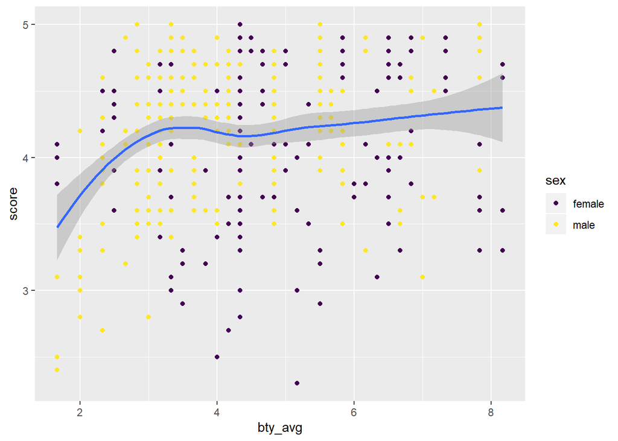

```r
evals %>%
  ggplot(aes(x = bty_avg, y = score)) +
  geom_point(aes(color = sex)) +
  geom_smooth() +
  scale_color_viridis_d()
```

**Bonus: Change the color of the plot you made for Questions 6 & 7.**